# Risk Factor Analysis

## Outcome Variable

**Outcome Variable:** stunted

## Predictor Variables

**Intervention Variable:** nhh

**Adjustment Set:**

- arm
- W_mage
- meducyrs
- feducyrs
- hhwealth_quart
- W_mhtcm
- W_mwtkg
- W_mbmi
- W_nrooms
- cleanck
- impfloor
- impsan
- safeh20
- delta_W_mage
- delta_meducyrs
- delta_feducyrs
- delta_hhwealth_quart
- delta_W_mhtcm
- delta_W_mwtkg
- delta_W_mbmi
- delta_W_nrooms
- delta_cleanck
- delta_impfloor
- delta_impsan
- delta_safeh20

## Stratifying Variables

The analysis was stratified on these variable(s):

- agecat
- studyid
- country

## Data Summary

| agecat | studyid | country | nhh | stunted | n_cell | n |
| --- | --- | --- | --- | --- | --- | --- |
| Birth | IRC | INDIA | 3 or less | 0 | 51 | 388 |
| Birth | IRC | INDIA | 3 or less | 1 | 3 | 388 |
| Birth | IRC | INDIA | 4-5 | 0 | 128 | 388 |
| Birth | IRC | INDIA | 4-5 | 1 | 22 | 388 |
| Birth | IRC | INDIA | 6-7 | 0 | 89 | 388 |
| Birth | IRC | INDIA | 6-7 | 1 | 14 | 388 |
| Birth | IRC | INDIA | 8+ | 0 | 75 | 388 |
| Birth | IRC | INDIA | 8+ | 1 | 6 | 388 |
| Birth | NIH-Birth | BANGLADESH | 3 or less | 0 | 93 | 608 |
| Birth | NIH-Birth | BANGLADESH | 3 or less | 1 | 19 | 608 |
| Birth | NIH-Birth | BANGLADESH | 4-5 | 0 | 214 | 608 |
| Birth | NIH-Birth | BANGLADESH | 4-5 | 1 | 41 | 608 |
| Birth | NIH-Birth | BANGLADESH | 6-7 | 0 | 118 | 608 |
| Birth | NIH-Birth | BANGLADESH | 6-7 | 1 | 20 | 608 |
| Birth | NIH-Birth | BANGLADESH | 8+ | 0 | 86 | 608 |
| Birth | NIH-Birth | BANGLADESH | 8+ | 1 | 17 | 608 |
| Birth | NIH-Crypto | BANGLADESH | 3 or less | 0 | 89 | 732 |
| Birth | NIH-Crypto | BANGLADESH | 3 or less | 1 | 19 | 732 |
| Birth | NIH-Crypto | BANGLADESH | 4-5 | 0 | 285 | 732 |
| Birth | NIH-Crypto | BANGLADESH | 4-5 | 1 | 43 | 732 |
| Birth | NIH-Crypto | BANGLADESH | 6-7 | 0 | 151 | 732 |
| Birth | NIH-Crypto | BANGLADESH | 6-7 | 1 | 25 | 732 |
| Birth | NIH-Crypto | BANGLADESH | 8+ | 0 | 106 | 732 |
| Birth | NIH-Crypto | BANGLADESH | 8+ | 1 | 14 | 732 |
| Birth | PROVIDE | BANGLADESH | 3 or less | 0 | 96 | 539 |
| Birth | PROVIDE | BANGLADESH | 3 or less | 1 | 8 | 539 |
| Birth | PROVIDE | BANGLADESH | 4-5 | 0 | 227 | 539 |
| Birth | PROVIDE | BANGLADESH | 4-5 | 1 | 24 | 539 |
| Birth | PROVIDE | BANGLADESH | 6-7 | 0 | 107 | 539 |
| Birth | PROVIDE | BANGLADESH | 6-7 | 1 | 9 | 539 |

[output cut: 90 more lines]

The following strata were considered:

- agecat: 24 months, studyid: IRC, country: INDIA
- agecat: 24 months, studyid: LCNI-5, country: MALAWI
- agecat: 24 months, studyid: NIH-Birth, country: BANGLADESH
- agecat: 24 months, studyid: NIH-Crypto, country: BANGLADESH
- agecat: 24 months, studyid: PROVIDE, country: BANGLADESH
- agecat: 6 months, studyid: IRC, country: INDIA
- agecat: 6 months, studyid: LCNI-5, country: MALAWI
- agecat: 6 months, studyid: NIH-Birth, country: BANGLADESH
- agecat: 6 months, studyid: NIH-Crypto, country: BANGLADESH
- agecat: 6 months, studyid: PROVIDE, country: BANGLADESH
- agecat: 6 months, studyid: SAS-FoodSuppl, country: INDIA
- agecat: Birth, studyid: IRC, country: INDIA
- agecat: Birth, studyid: NIH-Birth, country: BANGLADESH
- agecat: Birth, studyid: NIH-Crypto, country: BANGLADESH
- agecat: Birth, studyid: PROVIDE, country: BANGLADESH

### Dropped Strata

Some strata were dropped due to rare outcomes:

- agecat: Birth, studyid: IRC, country: INDIA

## Methods Detail

We’re interested in the causal parameters $E[Y_a]$ for all values of $a \in \mathcal{A}$. These parameters represent the mean outcome if, possibly contrary to fact, we intervened to set all units to have $A=a$. Under the randomization and positivity assumptions, these are identified by the statistical parameters $\psi_a=E_W[E_{Y|A,W}(Y|A=a,W)]$. In addition, we’re interested in the mean of $Y$, $E[Y]$ under no intervention (the observed mean). We will estimate these parameters by using SuperLearner to fit the relevant likelihood factors – $E_{Y|A,W}(Y|A=a,W)$ and $p(A=a|W)$, and then updating our likelihood fit using a joint TMLE.

For unadjusted analyses ($W=\{\}$), initial likelihoods were estimated using Lrnr_glm to estimate the simple $E(Y|A)$ and Lrnr_mean to estimate $p(A)$. For adjusted analyses, a small library containing Lrnr_glmnet, Lrnr_xgboost, and Lrnr_mean was used.

Having estimated these parameters, we will then use the delta method to estimate relative risks and attributable risks relative to a prespecified baseline level of $A$.

# Results Detail

## Results Plots

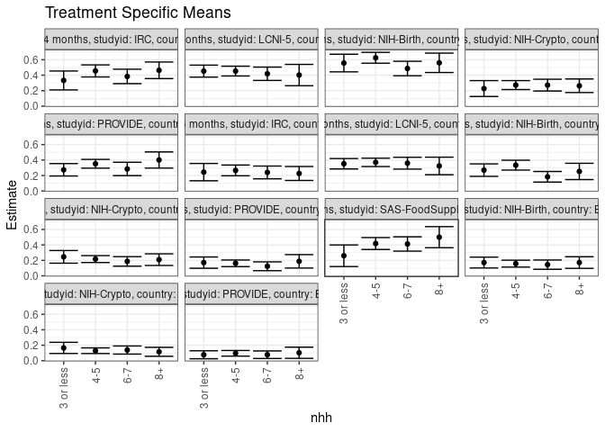

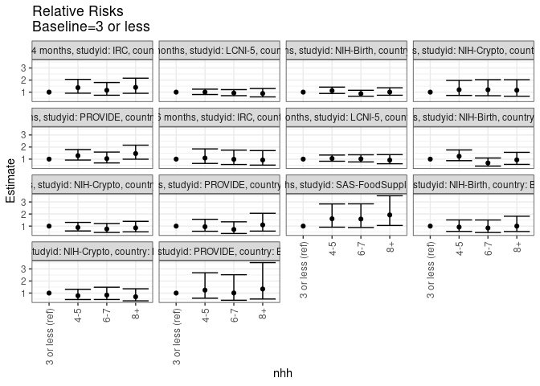

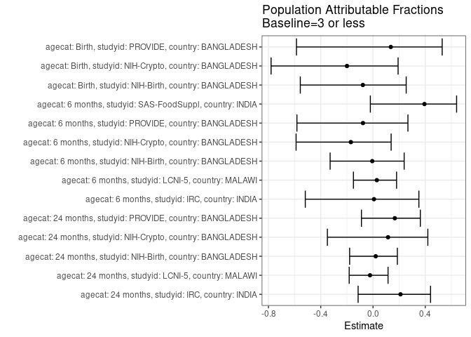

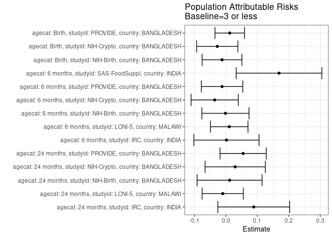

## Results Table

### Parameter: TSM

| agecat | studyid | country | intervention_level | baseline_level | estimate | ci_lower | ci_upper |
| --- | --- | --- | --- | --- | --- | --- | --- |
| Birth | NIH-Birth | BANGLADESH | 3 or less | NA | 0.1719119 | 0.1016304 | 0.2421934 |
| Birth | NIH-Birth | BANGLADESH | 4-5 | NA | 0.1579927 | 0.1132404 | 0.2027449 |
| Birth | NIH-Birth | BANGLADESH | 6-7 | NA | 0.1449732 | 0.0850980 | 0.2048483 |
| Birth | NIH-Birth | BANGLADESH | 8+ | NA | 0.1719454 | 0.0968880 | 0.2470029 |
| Birth | NIH-Crypto | BANGLADESH | 3 or less | NA | 0.1654801 | 0.0933657 | 0.2375946 |
| Birth | NIH-Crypto | BANGLADESH | 4-5 | NA | 0.1294266 | 0.0928794 | 0.1659738 |
| Birth | NIH-Crypto | BANGLADESH | 6-7 | NA | 0.1379555 | 0.0857585 | 0.1901524 |
| Birth | NIH-Crypto | BANGLADESH | 8+ | NA | 0.1151247 | 0.0572996 | 0.1729497 |
| Birth | PROVIDE | BANGLADESH | 3 or less | NA | 0.0769231 | 0.0256627 | 0.1281835 |
| Birth | PROVIDE | BANGLADESH | 4-5 | NA | 0.0956175 | 0.0592043 | 0.1320308 |
| Birth | PROVIDE | BANGLADESH | 6-7 | NA | 0.0775862 | 0.0288583 | 0.1263141 |
| Birth | PROVIDE | BANGLADESH | 8+ | NA | 0.1029412 | 0.0306472 | 0.1752351 |
| 6 months | IRC | INDIA | 3 or less | NA | 0.2438848 | 0.1321104 | 0.3556593 |
| 6 months | IRC | INDIA | 4-5 | NA | 0.2658625 | 0.1966130 | 0.3351120 |
| 6 months | IRC | INDIA | 6-7 | NA | 0.2400654 | 0.1576735 | 0.3224572 |
| 6 months | IRC | INDIA | 8+ | NA | 0.2265297 | 0.1362306 | 0.3168288 |
| 6 months | LCNI-5 | MALAWI | 3 or less | NA | 0.3521511 | 0.2847029 | 0.4195992 |
| 6 months | LCNI-5 | MALAWI | 4-5 | NA | 0.3701836 | 0.3161094 | 0.4242578 |
| 6 months | LCNI-5 | MALAWI | 6-7 | NA | 0.3592801 | 0.2831086 | 0.4354516 |
| 6 months | LCNI-5 | MALAWI | 8+ | NA | 0.3238998 | 0.2103253 | 0.4374742 |
| 6 months | NIH-Birth | BANGLADESH | 3 or less | NA | 0.2696880 | 0.1887869 | 0.3505891 |
| 6 months | NIH-Birth | BANGLADESH | 4-5 | NA | 0.3339134 | 0.2703167 | 0.3975101 |
| 6 months | NIH-Birth | BANGLADESH | 6-7 | NA | 0.1834949 | 0.1148368 | 0.2521531 |
| 6 months | NIH-Birth | BANGLADESH | 8+ | NA | 0.2527679 | 0.1474682 | 0.3580677 |
| 6 months | NIH-Crypto | BANGLADESH | 3 or less | NA | 0.2453958 | 0.1636779 | 0.3271138 |
| 6 months | NIH-Crypto | BANGLADESH | 4-5 | NA | 0.2168755 | 0.1721012 | 0.2616498 |
| 6 months | NIH-Crypto | BANGLADESH | 6-7 | NA | 0.1868545 | 0.1251964 | 0.2485126 |
| 6 months | NIH-Crypto | BANGLADESH | 8+ | NA | 0.2095286 | 0.1342298 | 0.2848273 |
| 6 months | PROVIDE | BANGLADESH | 3 or less | NA | 0.1711442 | 0.0982106 | 0.2440777 |
| 6 months | PROVIDE | BANGLADESH | 4-5 | NA | 0.1621425 | 0.1195141 | 0.2047710 |
| 6 months | PROVIDE | BANGLADESH | 6-7 | NA | 0.1238239 | 0.0667277 | 0.1809201 |
| 6 months | PROVIDE | BANGLADESH | 8+ | NA | 0.1879305 | 0.1010372 | 0.2748238 |
| 6 months | SAS-FoodSuppl | INDIA | 3 or less | NA | 0.2600360 | 0.1203706 | 0.3997015 |
| 6 months | SAS-FoodSuppl | INDIA | 4-5 | NA | 0.4179880 | 0.3409952 | 0.4949809 |
| 6 months | SAS-FoodSuppl | INDIA | 6-7 | NA | 0.4120912 | 0.3195682 | 0.5046141 |
| 6 months | SAS-FoodSuppl | INDIA | 8+ | NA | 0.4998923 | 0.3636735 | 0.6361112 |
| 24 months | IRC | INDIA | 3 or less | NA | 0.3320046 | 0.2098288 | 0.4541803 |
| 24 months | IRC | INDIA | 4-5 | NA | 0.4552020 | 0.3769993 | 0.5334048 |
| 24 months | IRC | INDIA | 6-7 | NA | 0.3839210 | 0.2906570 | 0.4771850 |
| 24 months | IRC | INDIA | 8+ | NA | 0.4630808 | 0.3560196 | 0.5701420 |
| 24 months | LCNI-5 | MALAWI | 3 or less | NA | 0.4526165 | 0.3753510 | 0.5298820 |
| 24 months | LCNI-5 | MALAWI | 4-5 | NA | 0.4531254 | 0.3898242 | 0.5164267 |
| 24 months | LCNI-5 | MALAWI | 6-7 | NA | 0.4184180 | 0.3321043 | 0.5047317 |
| 24 months | LCNI-5 | MALAWI | 8+ | NA | 0.4017465 | 0.2640949 | 0.5393980 |
| 24 months | NIH-Birth | BANGLADESH | 3 or less | NA | 0.5570198 | 0.4431758 | 0.6708638 |
| 24 months | NIH-Birth | BANGLADESH | 4-5 | NA | 0.6249920 | 0.5548854 | 0.6950987 |
| 24 months | NIH-Birth | BANGLADESH | 6-7 | NA | 0.4862350 | 0.3928704 | 0.5795995 |
| 24 months | NIH-Birth | BANGLADESH | 8+ | NA | 0.5598719 | 0.4346570 | 0.6850868 |
| 24 months | NIH-Crypto | BANGLADESH | 3 or less | NA | 0.2272427 | 0.1247103 | 0.3297751 |
| 24 months | NIH-Crypto | BANGLADESH | 4-5 | NA | 0.2722781 | 0.2144363 | 0.3301200 |
| 24 months | NIH-Crypto | BANGLADESH | 6-7 | NA | 0.2717479 | 0.1954673 | 0.3480286 |
| 24 months | NIH-Crypto | BANGLADESH | 8+ | NA | 0.2633197 | 0.1754369 | 0.3512024 |
| 24 months | PROVIDE | BANGLADESH | 3 or less | NA | 0.2738902 | 0.1936107 | 0.3541697 |
| 24 months | PROVIDE | BANGLADESH | 4-5 | NA | 0.3518957 | 0.2953442 | 0.4084472 |
| 24 months | PROVIDE | BANGLADESH | 6-7 | NA | 0.2850721 | 0.1988033 | 0.3713408 |
| 24 months | PROVIDE | BANGLADESH | 8+ | NA | 0.4005557 | 0.2960401 | 0.5050714 |

### Parameter: E(Y)

| agecat | studyid | country | intervention_level | baseline_level | estimate | ci_lower | ci_upper |
| --- | --- | --- | --- | --- | --- | --- | --- |
| Birth | NIH-Birth | BANGLADESH | NA | NA | 0.1595395 | 0.1304091 | 0.1886699 |
| Birth | NIH-Crypto | BANGLADESH | NA | NA | 0.1379781 | 0.1129774 | 0.1629789 |
| Birth | PROVIDE | BANGLADESH | NA | NA | 0.0890538 | 0.0649864 | 0.1131212 |
| 6 months | IRC | INDIA | NA | NA | 0.2457002 | 0.2038248 | 0.2875757 |
| 6 months | LCNI-5 | MALAWI | NA | NA | 0.3627451 | 0.3297365 | 0.3957537 |
| 6 months | NIH-Birth | BANGLADESH | NA | NA | 0.2681564 | 0.2306532 | 0.3056597 |
| 6 months | NIH-Crypto | BANGLADESH | NA | NA | 0.2097902 | 0.1799252 | 0.2396552 |
| 6 months | PROVIDE | BANGLADESH | NA | NA | 0.1589404 | 0.1297581 | 0.1881227 |
| 6 months | SAS-FoodSuppl | INDIA | NA | NA | 0.4289474 | 0.3791199 | 0.4787748 |
| 24 months | IRC | INDIA | NA | NA | 0.4205379 | 0.3726382 | 0.4684376 |
| 24 months | LCNI-5 | MALAWI | NA | NA | 0.4425087 | 0.4018409 | 0.4831765 |
| 24 months | NIH-Birth | BANGLADESH | NA | NA | 0.5687646 | 0.5218455 | 0.6156837 |
| 24 months | NIH-Crypto | BANGLADESH | NA | NA | 0.2568093 | 0.2190047 | 0.2946140 |
| 24 months | PROVIDE | BANGLADESH | NA | NA | 0.3287197 | 0.2903909 | 0.3670485 |

### Parameter: RR

| agecat | studyid | country | intervention_level | baseline_level | estimate | ci_lower | ci_upper |
| --- | --- | --- | --- | --- | --- | --- | --- |
| Birth | NIH-Birth | BANGLADESH | 3 or less | 3 or less | 1.0000000 | 1.0000000 | 1.000000 |
| Birth | NIH-Birth | BANGLADESH | 4-5 | 3 or less | 0.9190326 | 0.5595831 | 1.509375 |
| Birth | NIH-Birth | BANGLADESH | 6-7 | 3 or less | 0.8432990 | 0.4721866 | 1.506085 |
| Birth | NIH-Birth | BANGLADESH | 8+ | 3 or less | 1.0001950 | 0.5503776 | 1.817643 |
| Birth | NIH-Crypto | BANGLADESH | 3 or less | 3 or less | 1.0000000 | 1.0000000 | 1.000000 |
| Birth | NIH-Crypto | BANGLADESH | 4-5 | 3 or less | 0.7821277 | 0.4658455 | 1.313147 |
| Birth | NIH-Crypto | BANGLADESH | 6-7 | 3 or less | 0.8336678 | 0.4680050 | 1.485032 |
| Birth | NIH-Crypto | BANGLADESH | 8+ | 3 or less | 0.6957008 | 0.3575601 | 1.353617 |
| Birth | PROVIDE | BANGLADESH | 3 or less | 3 or less | 1.0000000 | 1.0000000 | 1.000000 |
| Birth | PROVIDE | BANGLADESH | 4-5 | 3 or less | 1.2430279 | 0.5769645 | 2.678013 |
| Birth | PROVIDE | BANGLADESH | 6-7 | 3 or less | 1.0086207 | 0.4036851 | 2.520072 |
| Birth | PROVIDE | BANGLADESH | 8+ | 3 or less | 1.3382353 | 0.5082528 | 3.523588 |
| 6 months | IRC | INDIA | 3 or less | 3 or less | 1.0000000 | 1.0000000 | 1.000000 |
| 6 months | IRC | INDIA | 4-5 | 3 or less | 1.0901150 | 0.6433551 | 1.847115 |
| 6 months | IRC | INDIA | 6-7 | 3 or less | 0.9843391 | 0.5549567 | 1.745944 |
| 6 months | IRC | INDIA | 8+ | 3 or less | 0.9288387 | 0.5059478 | 1.705198 |
| 6 months | LCNI-5 | MALAWI | 3 or less | 3 or less | 1.0000000 | 1.0000000 | 1.000000 |
| 6 months | LCNI-5 | MALAWI | 4-5 | 3 or less | 1.0512068 | 0.8259859 | 1.337839 |
| 6 months | LCNI-5 | MALAWI | 6-7 | 3 or less | 1.0202442 | 0.7666906 | 1.357651 |
| 6 months | LCNI-5 | MALAWI | 8+ | 3 or less | 0.9197751 | 0.6167688 | 1.371642 |
| 6 months | NIH-Birth | BANGLADESH | 3 or less | 3 or less | 1.0000000 | 1.0000000 | 1.000000 |
| 6 months | NIH-Birth | BANGLADESH | 4-5 | 3 or less | 1.2381472 | 0.8712698 | 1.759510 |
| 6 months | NIH-Birth | BANGLADESH | 6-7 | 3 or less | 0.6803971 | 0.4232312 | 1.093823 |
| 6 months | NIH-Birth | BANGLADESH | 8+ | 3 or less | 0.9372605 | 0.5625224 | 1.561640 |
| 6 months | NIH-Crypto | BANGLADESH | 3 or less | 3 or less | 1.0000000 | 1.0000000 | 1.000000 |
| 6 months | NIH-Crypto | BANGLADESH | 4-5 | 3 or less | 0.8837783 | 0.5978234 | 1.306513 |
| 6 months | NIH-Crypto | BANGLADESH | 6-7 | 3 or less | 0.7614412 | 0.4765198 | 1.216723 |
| 6 months | NIH-Crypto | BANGLADESH | 8+ | 3 or less | 0.8538392 | 0.5235754 | 1.392429 |
| 6 months | PROVIDE | BANGLADESH | 3 or less | 3 or less | 1.0000000 | 1.0000000 | 1.000000 |
| 6 months | PROVIDE | BANGLADESH | 4-5 | 3 or less | 0.9474032 | 0.5740957 | 1.563455 |
| 6 months | PROVIDE | BANGLADESH | 6-7 | 3 or less | 0.7235063 | 0.3861067 | 1.355743 |
| 6 months | PROVIDE | BANGLADESH | 8+ | 3 or less | 1.0980830 | 0.5854615 | 2.059548 |
| 6 months | SAS-FoodSuppl | INDIA | 3 or less | 3 or less | 1.0000000 | 1.0000000 | 1.000000 |
| 6 months | SAS-FoodSuppl | INDIA | 4-5 | 3 or less | 1.6074235 | 0.9111892 | 2.835646 |
| 6 months | SAS-FoodSuppl | INDIA | 6-7 | 3 or less | 1.5847464 | 0.8839466 | 2.841146 |
| 6 months | SAS-FoodSuppl | INDIA | 8+ | 3 or less | 1.9223965 | 1.0524262 | 3.511513 |
| 24 months | IRC | INDIA | 3 or less | 3 or less | 1.0000000 | 1.0000000 | 1.000000 |
| 24 months | IRC | INDIA | 4-5 | 3 or less | 1.3710716 | 0.9133717 | 2.058130 |
| 24 months | IRC | INDIA | 6-7 | 3 or less | 1.1563727 | 0.7439553 | 1.797417 |
| 24 months | IRC | INDIA | 8+ | 3 or less | 1.3948024 | 0.9031040 | 2.154208 |
| 24 months | LCNI-5 | MALAWI | 3 or less | 3 or less | 1.0000000 | 1.0000000 | 1.000000 |
| 24 months | LCNI-5 | MALAWI | 4-5 | 3 or less | 1.0011243 | 0.8036904 | 1.247060 |
| 24 months | LCNI-5 | MALAWI | 6-7 | 3 or less | 0.9244426 | 0.7075703 | 1.207787 |
| 24 months | LCNI-5 | MALAWI | 8+ | 3 or less | 0.8876090 | 0.6056712 | 1.300788 |
| 24 months | NIH-Birth | BANGLADESH | 3 or less | 3 or less | 1.0000000 | 1.0000000 | 1.000000 |
| 24 months | NIH-Birth | BANGLADESH | 4-5 | 3 or less | 1.1220284 | 0.8892804 | 1.415693 |
| 24 months | NIH-Birth | BANGLADESH | 6-7 | 3 or less | 0.8729223 | 0.6621661 | 1.150759 |
| 24 months | NIH-Birth | BANGLADESH | 8+ | 3 or less | 1.0051204 | 0.7430559 | 1.359611 |
| 24 months | NIH-Crypto | BANGLADESH | 3 or less | 3 or less | 1.0000000 | 1.0000000 | 1.000000 |
| 24 months | NIH-Crypto | BANGLADESH | 4-5 | 3 or less | 1.1981820 | 0.7281305 | 1.971680 |
| 24 months | NIH-Crypto | BANGLADESH | 6-7 | 3 or less | 1.1958489 | 0.7047130 | 2.029272 |
| 24 months | NIH-Crypto | BANGLADESH | 8+ | 3 or less | 1.1587596 | 0.6622792 | 2.027429 |
| 24 months | PROVIDE | BANGLADESH | 3 or less | 3 or less | 1.0000000 | 1.0000000 | 1.000000 |
| 24 months | PROVIDE | BANGLADESH | 4-5 | 3 or less | 1.2848055 | 0.9223329 | 1.789728 |
| 24 months | PROVIDE | BANGLADESH | 6-7 | 3 or less | 1.0408260 | 0.6842352 | 1.583255 |
| 24 months | PROVIDE | BANGLADESH | 8+ | 3 or less | 1.4624682 | 0.9920439 | 2.155966 |

### Parameter: PAR

| agecat | studyid | country | intervention_level | baseline_level | estimate | ci_lower | ci_upper |
| --- | --- | --- | --- | --- | --- | --- | --- |
| Birth | NIH-Birth | BANGLADESH | 3 or less | NA | -0.0123724 | -0.0756043 | 0.0508594 |
| Birth | NIH-Crypto | BANGLADESH | 3 or less | NA | -0.0275020 | -0.0930841 | 0.0380801 |
| Birth | PROVIDE | BANGLADESH | 3 or less | NA | 0.0121307 | -0.0346973 | 0.0589588 |
| 6 months | IRC | INDIA | 3 or less | NA | 0.0018154 | -0.1018392 | 0.1054701 |
| 6 months | LCNI-5 | MALAWI | 3 or less | NA | 0.0105940 | -0.0490202 | 0.0702083 |
| 6 months | NIH-Birth | BANGLADESH | 3 or less | NA | -0.0015316 | -0.0765241 | 0.0734609 |
| 6 months | NIH-Crypto | BANGLADESH | 3 or less | NA | -0.0356056 | -0.1107271 | 0.0395158 |
| 6 months | PROVIDE | BANGLADESH | 3 or less | NA | -0.0122038 | -0.0781204 | 0.0537129 |
| 6 months | SAS-FoodSuppl | INDIA | 3 or less | NA | 0.1689113 | 0.0327365 | 0.3050862 |
| 24 months | IRC | INDIA | 3 or less | NA | 0.0885333 | -0.0257247 | 0.2027914 |
| 24 months | LCNI-5 | MALAWI | 3 or less | NA | -0.0101078 | -0.0756588 | 0.0554432 |
| 24 months | NIH-Birth | BANGLADESH | 3 or less | NA | 0.0117448 | -0.0915467 | 0.1150362 |
| 24 months | NIH-Crypto | BANGLADESH | 3 or less | NA | 0.0295666 | -0.0662544 | 0.1253877 |
| 24 months | PROVIDE | BANGLADESH | 3 or less | NA | 0.0548295 | -0.0185633 | 0.1282223 |

### Parameter: PAF

| agecat | studyid | country | intervention_level | baseline_level | estimate | ci_lower | ci_upper |
| --- | --- | --- | --- | --- | --- | --- | --- |
| Birth | NIH-Birth | BANGLADESH | 3 or less | NA | -0.0775510 | -0.5564547 | 0.2539993 |
| Birth | NIH-Crypto | BANGLADESH | 3 or less | NA | -0.1993214 | -0.7801386 | 0.1919888 |
| Birth | PROVIDE | BANGLADESH | 3 or less | NA | 0.1362179 | -0.5857997 | 0.5294996 |
| 6 months | IRC | INDIA | 3 or less | NA | 0.0073888 | -0.5183129 | 0.3510711 |
| 6 months | LCNI-5 | MALAWI | 3 or less | NA | 0.0292052 | -0.1498166 | 0.1803540 |
| 6 months | NIH-Birth | BANGLADESH | 3 or less | NA | -0.0057115 | -0.3282154 | 0.2384853 |
| 6 months | NIH-Crypto | BANGLADESH | 3 or less | NA | -0.1697201 | -0.5887191 | 0.1387746 |
| 6 months | PROVIDE | BANGLADESH | 3 or less | NA | -0.0767822 | -0.5823874 | 0.2672718 |
| 6 months | SAS-FoodSuppl | INDIA | 3 or less | NA | 0.3937811 | -0.0203431 | 0.6398257 |
| 24 months | IRC | INDIA | 3 or less | NA | 0.2105240 | -0.1139680 | 0.4404935 |
| 24 months | LCNI-5 | MALAWI | 3 or less | NA | -0.0228421 | -0.1822496 | 0.1150719 |
| 24 months | NIH-Birth | BANGLADESH | 3 or less | NA | 0.0206496 | -0.1789148 | 0.1864322 |
| 24 months | NIH-Crypto | BANGLADESH | 3 or less | NA | 0.1151307 | -0.3492233 | 0.4196708 |
| 24 months | PROVIDE | BANGLADESH | 3 or less | NA | 0.1667971 | -0.0884967 | 0.3622148 |